# Predicción de Zonas con Alta Contaminación por PM2.5

### 2.1.3 Eliminación recursiva de variables (RFE)

Para mantener la interpretabilidad de las variables y mejorar la eficiencia del modelo, se aplica un método de selección de variables basado en eliminación recursiva (Recursive Feature Elimination, RFE), utilizando árboles aleatorios como modelo base y validación cruzada para evaluar el rendimiento en distintos subconjuntos de variables.

```r
# Asegurar que bundesland es factor
datosTrain$bundesland <- as.factor(datosTrain$bundesland)

# Separar predictores (x) y target (y)
x <- datosTrain[, setdiff(names(datosTrain), "PM2.5_categoria")]
y <- datosTrain$PM2.5_categoria

# RFE control setup
cl <- makeCluster(detectCores() - 1)
registerDoParallel(cl)

set.seed(123)
subsets <- 3:12
seeds <- vector(mode = "list", length = 6)
for(i in 1:5) seeds[[i]] <- sample.int(1000, length(subsets) + 1)
seeds[[6]] <- sample.int(1000, 1)

ctrl.rfe <- rfeControl(
  functions = rfFuncs,
  method = "cv",
  number = 5,
  seeds = seeds,
  returnResamp = "final",
  verbose = FALSE,
  allowParallel = TRUE
)

# Ejecutar RFE sin fórmula, pasando x e y por separado
modelo_rfe <- rfe(x = x, y = y, sizes = subsets, rfeControl = ctrl.rfe)

# Guardar y detener el clúster
saveRDS(modelo_rfe, file.path(ruta, file = "modelo_rfe_pm25_sinyear.rds"))
stopCluster(cl)
```

```r
modelo_rfe <- readRDS(file.path(ruta,"modelo_rfe_pm25_sinyear.rds"))
print(modelo_rfe)
```

```
##
## Recursive feature selection
##
## Outer resampling method: Cross-Validated (5 fold)
##
## Resampling performance over subset size:
##
##  Variables Accuracy  Kappa AccuracySD  KappaSD Selected
##          3   0.9341 0.7653  0.0041658 0.013874
##          4   0.9615 0.8668  0.0034585 0.011120
##          5   0.9665 0.8843  0.0049699 0.016895
##          6   0.9694 0.8941  0.0016403 0.005873        *
##          7   0.9689 0.8921  0.0009972 0.003863
##          8   0.9680 0.8885  0.0014712 0.005380
##          9   0.9669 0.8849  0.0021803 0.007378
##         10   0.9673 0.8859  0.0013019 0.004580
##         11   0.9669 0.8844  0.0022422 0.007825
##
## The top 5 variables (out of 6):
##    PM10_annualMean, bundesland, PM10_daysOver50, NO_annualMean, NO2_annualMean
```

```r
opt_vars <- modelo_rfe$optVariables
opt_vars
```

```
## [1] "PM10_annualMean" "bundesland"      "PM10_daysOver50" "NO_annualMean"
## [5] "NO2_annualMean"  "O3_annualMean"
```

El proceso de selección identifica un conjunto óptimo de seis variables predictoras que proporciona el mejor equilibrio entre rendimiento y simplicidad del modelo. Estas variables son: `PM10_annualMean`, `bundesland`, `PM10_daysOver50`, `NO_annualMean`, `NO2_annualMean` y `O3_annualMean`. Este conjunto se utilizará en el entrenamiento de los modelos posteriores.

## 2.2 Entrenamiento de modelos predictivos

### 2.2.1 Preprocesamiento y variable de control

Utilizando las variables seleccionadas mediante RFE, se construyen nuevos conjuntos de entrenamiento y prueba. Para corregir el desequilibrio de clases, se aplica la técnica `SMOTE` (Synthetic Minority Over-sampling Technique) durante la validación cruzada, lo que permite aumentar el rendimiento predictivo sobre las clases menos representadas.

```r
trainData <- datosTrain[, c(opt_vars, "PM2.5_categoria")]
testData  <- datosTest[,  c(opt_vars, "PM2.5_categoria")]

saveRDS(trainData, file.path(ruta, "trainData_sinyear.rds"))
saveRDS(testData,  file.path(ruta, "testData_sinyear.rds"))

# Se corrigen nombres de niveles en el target
trainData$PM2.5_categoria <- factor(trainData$PM2.5_categoria)
testData$PM2.5_categoria <- factor(testData$PM2.5_categoria)

levels(trainData$PM2.5_categoria) <- make.names(levels(trainData$PM2.5_categoria))
levels(testData$PM2.5_categoria) <- make.names(levels(testData$PM2.5_categoria))
```

Aquí se crea la variable de control que se empleará en todos los modelos donde se especifican los siguientes parámetros:

- Se establece una **validación cruzada** de 5 particiones (`method = "cv"`, `number = 5`) para evaluar el rendimiento de los modelos de forma robusta.
- Se aplica la técnica de re-muestreo **SMOTE** (`sampling = "smote"`) dentro de cada pliegue, lo que permite generar observaciones sintéticas de las clases minoritarias durante el entrenamiento, equilibrando las clases.
- Se activan las **probabilidades de clase** (`classProbs = TRUE`) y se utiliza multiClassSummary como función de evaluación, la cual calcula métricas específicas para clasificación multiclase como Accuracy, Kappa, Sensibilidad y Especificidad por clase.
- Además, se guarda la **predicción final** de cada modelo (`savePredictions = "final"`) y se permite el uso de procesamiento en **paralelo** (`allowParallel = TRUE`) para acelerar la ejecución.

```r
set.seed(123)
ctrl_smote <- trainControl(
  method = "cv",
  number = 5,
  sampling = "smote",
  classProbs = TRUE,
  summaryFunction = multiClassSummary,
  savePredictions = "final",
  allowParallel = TRUE
)
```

**Nota**

Se realizaron los experimentos con upsampling y se seleccionó SMOTE como método de balanceo ya que se obtuvieron mejores resultados.

### 2.2.2 Modelo 1. Random Forest

Se entrena un modelo Random Forest utilizando las variables seleccionadas. Para llevar a cabo el entrenamiento del modelo, se activa primero el procesamiento en paralelo mediante la creación de un clúster que utiliza todos los núcleos disponibles del sistema menos uno (`makeCluster(detectCores() - 1)`), lo que permite acelerar el proceso de entrenamiento. Este clúster se registra con `registerDoParallel()`.

A continuación, se entrena un modelo de tipo Random Forest utilizando la función `train()` del paquete caret. La variable objetivo es `PM2.5_categoria`, y se utilizan como predictores todas las demás variables del conjunto `trainData`. Se emplea como métrica principal de evaluación el coeficiente Kappa, apropiado para problemas de clasificación multiclase y con clases desbalanceadas.

El objeto `ctrl_smote`, definido previamente, permite aplicar la técnica SMOTE durante el entrenamiento, mejorando la representación de las clases minoritarias en cada pliegue de validación cruzada. Además, los datos se escalan y centran automáticamente (`preProcess = c("center", "scale")`) para mejorar el rendimiento del modelo.

La búsqueda de hiperparámetros se realiza de forma automática con `tuneLength = 3`, que explora tres combinaciones distintas de parámetros del algoritmo.

Finalmente, el modelo entrenado se guarda como archivo .rds con `saveRDS()` para su uso posterior, y se detiene el clúster paralelo con `stopCluster(cl)` para liberar los recursos.

```r
cl <- makeCluster(detectCores() - 1)
registerDoParallel(cl)

set.seed(342)
modelo_rf_smote <- caret::train(
  PM2.5_categoria ~ .,
  data = trainData,
  method = "rf",
  metric = "Kappa",
  trControl = ctrl_smote,
  tuneLength = 3,
  preProcess = c("center", "scale")
)

saveRDS(modelo_rf_smote, file.path(ruta, file = "modelo_rf_smote_sinyear.rds"))
stopCluster(cl)
```

Mediante el siguiente código se recupera el modelo sin necesidad de reevaluar el código cada vez que se ejecuta el documento y obtenemos los resultados del modelo Random Forest con Smote.

```r
# Recuperamos el modelo
modelo_rf_smote <- readRDS(file.path(ruta,"modelo_rf_smote_sinyear.rds"))
print(modelo_rf_smote)
```

```
## Random Forest
##
## 15540 samples
##     6 predictor
##     4 classes: 'Bajo', 'Moderado', 'Insalubre', 'Muy.Insalubre'
##
## Pre-processing: centered (20), scaled (20)
## Resampling: Cross-Validated (5 fold)
## Summary of sample sizes: 12433, 12431, 12431, 12433, 12432
## Addtional sampling using SMOTE prior to pre-processing
##
## Resampling results across tuning parameters:
##
##   mtry  logLoss    AUC        prAUC      Accuracy   Kappa      Mean_F1
##    2    0.3201643  0.9682141  0.6484806  0.8937577  0.6854003  0.6221292
##   11    0.1235328  0.9915916  0.6151822  0.9669240  0.8897576  0.8476926
##   20    0.1758946  0.9729864  0.4778571  0.9625484  0.8762412  0.8168443
##   Mean_Sensitivity  Mean_Specificity  Mean_Pos_Pred_Value  Mean_Neg_Pred_Value
##   0.8496517         0.9438572         0.5489647            0.9083297
##   0.8747232         0.9737719         0.8284140            0.9721107
##   0.8559924         0.9723273         0.7905855            0.9671844
##   Mean_Precision  Mean_Recall  Mean_Detection_Rate  Mean_Balanced_Accuracy
##   0.5489647       0.8496517    0.2234394            0.8967544
##   0.8284140       0.8747232    0.2417310            0.9242476
##   0.7905855       0.8559924    0.2406371            0.9141598
##
## Kappa was used to select the optimal model using the largest value.
## The final value used for the model was mtry = 11.
```

Se ha entrenado un modelo de Random Forest utilizando validación cruzada de 5 pliegues y aplicando SMOTE para corregir el desbalance en la variable objetivo PM2.5_categoria. El conjunto de entrenamiento contiene 15.540 observaciones, 6 variables predictoras y una variable de salida con 4 clases: Bajo, Moderado, Insalubre y Muy.Insalubre. El preprocesamiento incluyó centrado y escalado de las variables, y se evaluaron tres valores diferentes para el hiperparámetro mtry.

Con mtry = 11, el modelo alcanzó el mejor rendimiento global, seleccionándose como óptimo según el coeficiente Kappa. Se obtuvo una Kappa = 0.8898, lo cual indica una muy buena concordancia entre las predicciones del modelo y las clases reales. La precisión global (Accuracy) fue de 96.7%, y la AUC (Área bajo la curva ROC) alcanzó un valor muy elevado de 0.9916, mostrando excelente capacidad discriminativa.

La media del F1-score también fue elevada (0.8477), lo que indica un buen equilibrio entre precisión y sensibilidad. El valor de logLoss = 0.1235 sugiere que el modelo realiza predicciones con alta confianza. A continuación, se procede a realizar predicciones con el conjunto de prueba y a mostrar la matriz de confusión.

```r
# Predicciones y matriz de confusión
pred_rf_smote <- predict(modelo_rf_smote, newdata = testData)
cm_rf_smote <- confusionMatrix(pred_rf_smote, testData$PM2.5_categoria)
print("Matriz de confusión RF:")
```

```
## [1] "Matriz de confusión RF:"
```

```r
cm_rf_smote
```

```
## Confusion Matrix and Statistics
##
##                Reference
## Prediction      Bajo Moderado Insalubre Muy.Insalubre
##   Bajo          1261       67         2             0
##   Moderado        84     6483         2             6
##   Insalubre        7       11        55             0
##   Muy.Insalubre    1        5         0            20
##
## Overall Statistics
##
##                Accuracy : 0.9769
##                  95% CI : (0.9734, 0.9801)
##     No Information Rate : 0.8203
##     P-Value [Acc > NIR] : < 2.2e-16
##
##                   Kappa : 0.9224
##
##  Mcnemar's Test P-Value : NA
##
## Statistics by Class:
##
##                      Class: Bajo Class: Moderado Class: Insalubre
## Sensitivity               0.9320          0.9874         0.932203
## Specificity               0.9896          0.9360         0.997734
## Pos Pred Value            0.9481          0.9860         0.753425
## Neg Pred Value            0.9862          0.9419         0.999496
## Prevalence                0.1690          0.8203         0.007371
## Detection Rate            0.1575          0.8100         0.006872
## Detection Prevalence      0.1662          0.8215         0.009120
## Balanced Accuracy         0.9608          0.9617         0.964969
##                      Class: Muy.Insalubre
## Sensitivity                      0.769231
## Specificity                      0.999248
## Pos Pred Value                   0.769231
## Neg Pred Value                   0.999248
## Prevalence                       0.003248
## Detection Rate                   0.002499
## Detection Prevalence             0.003248
## Balanced Accuracy                0.884239
```

La matriz de confusión revela una capacidad de predicción especialmente alta en las clases “Bajo” y “Moderado”, que representan la mayoría de los casos. También se observa una buena sensibilidad en las clases minoritarias, aunque con precisión algo más limitada, como es habitual en escenarios con clases desbalanceadas. Estos resultados indican que el modelo Random Forest, combinado con SMOTE, ofrece una buena solución para la clasificación de niveles de contaminación atmosférica.

### 2.2.3 Modelo 2. Support Vector Machine (SVM) Radial

Se entrena un modelo de SVM con kernel radial (`svmRadial`) utilizando la misma configuración general que en el modelo anterior: validación cruzada de 5 pliegues, técnica SMOTE para el balanceo de clases, y preprocesamiento con centrado y escalado de las variables. El ajuste se realiza con `tuneLength = 3`, lo que permite explorar diferentes combinaciones de hiperparámetros. El rendimiento del modelo se evalúa empleando el coeficiente Kappa como métrica principal. Una vez entrenado, el modelo se guarda en formato `.rds` para facilitar su reutilización posterior.

```r
# SVM Radial
cl <- makeCluster(detectCores() - 1)
registerDoParallel(cl)

set.seed(342)
modelo_svm <- caret::train(
  PM2.5_categoria ~ .,
  data = trainData,
  method = "svmRadial",
  metric = "Kappa",
  trControl = ctrl_smote,
  tuneLength = 3,
  preProcess = c("center", "scale")
)

saveRDS(modelo_svm, file.path(ruta, file = "modelo_svm_smote_sinyear.rds"))
stopCluster(cl)
```

Tras el entrenamiento se recupera el modelo mediante el siguiente código y se observan los resultados.

```r
# Recuperamos el modelo
modelo_svm_smote <- readRDS(file.path(ruta,"modelo_svm_smote_sinyear.rds"))
print(modelo_svm_smote)
```

```
## Support Vector Machines with Radial Basis Function Kernel
##
## 15540 samples
##     6 predictor
##     4 classes: 'Bajo', 'Moderado', 'Insalubre', 'Muy.Insalubre'
##
## Pre-processing: centered (20), scaled (20)
## Resampling: Cross-Validated (5 fold)
## Summary of sample sizes: 12433, 12431, 12431, 12433, 12432
## Addtional sampling using SMOTE prior to pre-processing
##
## Resampling results across tuning parameters:
##
##   C     logLoss    AUC        prAUC      Accuracy   Kappa      Mean_F1
##   0.25  0.3598075  0.9538963  0.6189437  0.8711714  0.6196357  0.5902273
##   0.50  0.3355398  0.9570183  0.6415467  0.8818539  0.6462065  0.6223371
##   1.00  0.3209420  0.9545898  0.6735476  0.8871951  0.6593700  0.6372771
##   Mean_Sensitivity  Mean_Specificity  Mean_Pos_Pred_Value  Mean_Neg_Pred_Value
##   0.6611140         0.9263726         0.5834276            0.8919728
##   0.6698965         0.9316132         0.6266048            0.8992192
##   0.6787338         0.9338261         0.6434958            0.9029474
##   Mean_Precision  Mean_Recall  Mean_Detection_Rate  Mean_Balanced_Accuracy
##   0.5834276       0.6611140    0.2177929            0.7937433
##   0.6266048       0.6698965    0.2204635            0.8007548
##   0.6434958       0.6787338    0.2217988            0.8062800
##
## Tuning parameter 'sigma' was held constant at a value of 0.06969905
## Kappa was used to select the optimal model using the largest value.
## The final values used for the model were sigma = 0.06969905 and C = 1.
```

Como conclusiones a estos resultados se puede confirmar que se probaron tres valores del hiperparámetro C, manteniendo sigma constante en 0.0697. El mejor rendimiento se obtuvo con C = 1, seleccionado por presentar el mayor valor de Kappa.

Los resultados de este modelo muestran un buen rendimiento general, alcanzando un Kappa de 0.659, una precisión media (Mean Precision) de 0.64 y un AUC de 0.954. Además, la exactitud del modelo es del 88.7%, con una sensibilidad media del 67.9% y una especificidad del 93.4%. Estos valores indican un comportamiento equilibrado, aunque aún existe margen de mejora en la predicción de clases menos representadas. Se realizan a continuación las predicciones y se observa la matriz de confusión.

```r
# Predicciones y matriz de confusión
pred_svm_smote <- predict(modelo_svm_smote, newdata = testData)
cm_svm_smote <- confusionMatrix(pred_svm_smote, testData$PM2.5_categoria)
print("Matriz de confusión SVM:")
```

```
## [1] "Matriz de confusión SVM:"
```

```r
cm_svm_smote
```

```
## Confusion Matrix and Statistics
##
##                Reference
## Prediction      Bajo Moderado Insalubre Muy.Insalubre
##   Bajo          1128      642         9             1
##   Moderado       217     5888        37             4
##   Insalubre        2       15        10             2
##   Muy.Insalubre    6       21         3            19
##
## Overall Statistics
##
##                Accuracy : 0.8802
##                  95% CI : (0.8729, 0.8872)
##     No Information Rate : 0.8203
##     P-Value [Acc > NIR] : < 2.2e-16
##
##                   Kappa : 0.6396
##
##  Mcnemar's Test P-Value : < 2.2e-16
##
## Statistics by Class:
##
##                      Class: Bajo Class: Moderado Class: Insalubre
## Sensitivity               0.8337          0.8967         0.169492
## Specificity               0.9020          0.8206         0.997609
## Pos Pred Value            0.6337          0.9580         0.344828
## Neg Pred Value            0.9638          0.6351         0.993856
## Prevalence                0.1690          0.8203         0.007371
## Detection Rate            0.1409          0.7356         0.001249
## Detection Prevalence      0.2224          0.7679         0.003623
## Balanced Accuracy         0.8678          0.8587         0.583550
##                      Class: Muy.Insalubre
## Sensitivity                      0.730769
## Specificity                      0.996240
## Pos Pred Value                   0.387755
## Neg Pred Value                   0.999120
## Prevalence                       0.003248
## Detection Rate                   0.002374
## Detection Prevalence             0.006122
## Balanced Accuracy                0.863504
```

El mejor rendimiento se obtiene con un parámetro C igual a 1, manteniéndose constante el valor de sigma.

Este modelo alcanza una exactitud del 88% y un Kappa de 0.64, lo que representa un rendimiento razonable aunque inferior al observado en el modelo Random Forest. La matriz de confusión muestra una mayor confusión entre las clases, particularmente entre “Bajo” y “Moderado”.

El modelo SVM presenta limitaciones en la detección de clases minoritarias como “Insalubre” y “Muy.Insalubre”, lo que podría deberse a la menor capacidad del clasificador para manejar relaciones no lineales complejas en presencia de clases desbalanceadas, incluso con la técnica SMOTE aplicada.

### 2.2.4 Modelo 3. Gradient Boosting Machine (GMB)

Para este modelo se utilizó el algoritmo Gradient Boosting Machine (GBM), junto con la técnica de sobremuestreo SMOTE (Synthetic Minority Over-sampling Technique), con el fin de equilibrar las clases minoritarias antes del preprocesamiento. La métrica seleccionada para la optimización fue Kappa y se aplicó validación cruzada de 5 pliegues al igual que en los casos anteriores.

```r
# Gradient Boosting Machine (GBM)
cl <- makeCluster(detectCores() - 1)
registerDoParallel(cl)

set.seed(342)
modelo_gbm <- caret::train(
  PM2.5_categoria ~ .,
  data = trainData,
  method = "gbm",
  verbose = FALSE,
  metric = "Kappa",
  trControl = ctrl_smote,
  tuneLength = 3,
  preProcess = c("center", "scale")
)
saveRDS(modelo_gbm, file.path(ruta, file = "modelo_gbm_smote_sinyear.rds"))
stopCluster(cl)
```

De la misma forma que en los modelos anteriores, se recupera el modelo GBM mediante el siguiente código y se observan los resultados.

```r
# Recuperamos el modelo
modelo_gbm_smote <- readRDS(file.path(ruta,"modelo_gbm_smote_sinyear.rds"))
print(modelo_gbm_smote)
```

```
## Stochastic Gradient Boosting
##
## 15540 samples
##     6 predictor
##     4 classes: 'Bajo', 'Moderado', 'Insalubre', 'Muy.Insalubre'
##
## Pre-processing: centered (20), scaled (20)
## Resampling: Cross-Validated (5 fold)
## Summary of sample sizes: 12433, 12431, 12431, 12433, 12432
## Addtional sampling using SMOTE prior to pre-processing
##
## Resampling results across tuning parameters:
##
##   interaction.depth  n.trees  logLoss    AUC        prAUC      Accuracy
##   1                   50      0.5489101  0.9357783  0.5294791  0.8253549
##   1                  100      0.4841622  0.9418825  0.5404913  0.8314675
##   1                  150      0.4534803  0.9455911  0.5610131  0.8380953
##   2                   50      0.4656842  0.9493083  0.5742933  0.8337839
##   2                  100      0.3886427  0.9545703  0.6024317  0.8514166
##   2                  150      0.3482025  0.9574713  0.6232956  0.8651229
##   3                   50      0.4088375  0.9553238  0.6031710  0.8463966
##   3                  100      0.3349779  0.9618541  0.6450819  0.8742602
##   3                  150      0.2996469  0.9650685  0.6682643  0.8925355
##   Kappa      Mean_F1    Mean_Sensitivity  Mean_Specificity  Mean_Pos_Pred_Value
##   0.5537298  0.4979773  0.7757655         0.9303777         0.4550699
##   0.5635162  0.5077426  0.8039082         0.9312698         0.4612819
##   0.5739881  0.5172397  0.8039925         0.9320990         0.4677920
##   0.5665348  0.5187784  0.8034132         0.9308851         0.4694857
##   0.5970270  0.5452724  0.8068617         0.9339924         0.4890007
##   0.6214961  0.5648810  0.8044054         0.9352301         0.5054822
##   0.5902236  0.5350197  0.8058682         0.9346922         0.4826539
##   0.6426885  0.5773126  0.8084071         0.9390890         0.5176028
##   0.6812272  0.6119431  0.8165661         0.9422433         0.5475091
##   Mean_Neg_Pred_Value  Mean_Precision  Mean_Recall  Mean_Detection_Rate
##   0.8722501            0.4550699       0.7757655    0.2063387
##   0.8746857            0.4612819       0.8039082    0.2078669
##   0.8775426            0.4677920       0.8039925    0.2095238
##   0.8754622            0.4694857       0.8034132    0.2084460
##   0.8836669            0.4890007       0.8068617    0.2128541
##   0.8906491            0.5054822       0.8044054    0.2162807
##   0.8815350            0.4826539       0.8058682    0.2115991
##   0.8961057            0.5176028       0.8084071    0.2185650
##   0.9077944            0.5475091       0.8165661    0.2231339
##   Mean_Balanced_Accuracy
##   0.8530716
##   0.8675890
##   0.8680457
##   0.8671491
##   0.8704270
##   0.8698178
##   0.8702802
##   0.8737480
##   0.8794047
##
## Tuning parameter 'shrinkage' was held constant at a value of 0.1
##
## Tuning parameter 'n.minobsinnode' was held constant at a value of 10
## Kappa was used to select the optimal model using the largest value.
## The final values used for the model were n.trees = 150, interaction.depth =
##  3, shrinkage = 0.1 and n.minobsinnode = 10.
```

El modelo de Gradient Boosting Machine (GBM) se ha ajustado utilizando una búsqueda sobre distintos valores de n.trees (50, 100, 150) y interaction.depth (1, 2, 3), manteniendo constantes los hiperparámetros shrinkage = 0.1 y n.minobsinnode = 10. El proceso de entrenamiento se ha basado en una validación cruzada de 5 pliegues, aplicando SMOTE antes del preprocesamiento para tratar el desbalance de clases.

El mejor rendimiento se obtiene con 150 árboles, una profundidad de interacción de 3, y destaca por un valor de Kappa de 0.681, junto con una AUC de 0.965 y una precisión media (Mean Precision) de 0.55. La exactitud del modelo alcanza el 89.3%, mostrando además un recall medio del 81.7% y una especificidad del 94.2%.

En conjunto, estos resultados reflejan que el modelo GBM ofrece un rendimiento competitivo, logrando un buen equilibrio entre sensibilidad y especificidad, especialmente tras el ajuste de hiperparámetros y el uso de técnicas de sobremuestreo.

```r
# Predicciones y matriz de confusión
pred_gbm_smote <- predict(modelo_gbm_smote, newdata = testData)
cm_gbm_smote <- confusionMatrix(pred_gbm_smote, testData$PM2.5_categoria)
print("Matriz de confusión SVM:")
```

```
## [1] "Matriz de confusión SVM:"
```

```r
cm_gbm_smote
```

```
## Confusion Matrix and Statistics
##
##                Reference
## Prediction      Bajo Moderado Insalubre Muy.Insalubre
##   Bajo          1111      426         1             0
##   Moderado       185     5928         8             3
##   Insalubre       45      168        48             2
##   Muy.Insalubre   12       44         2            21
##
## Overall Statistics
##
##                Accuracy : 0.8881
##                  95% CI : (0.8809, 0.8949)
##     No Information Rate : 0.8203
##     P-Value [Acc > NIR] : < 2.2e-16
##
##                   Kappa : 0.6704
##
##  Mcnemar's Test P-Value : < 2.2e-16
##
## Statistics by Class:
##
##                      Class: Bajo Class: Moderado Class: Insalubre
## Sensitivity               0.8211          0.9028         0.813559
## Specificity               0.9358          0.8637         0.972939
## Pos Pred Value            0.7224          0.9680         0.182510
## Neg Pred Value            0.9626          0.6606         0.998579
## Prevalence                0.1690          0.8203         0.007371
## Detection Rate            0.1388          0.7406         0.005997
## Detection Prevalence      0.1922          0.7651         0.032859
## Balanced Accuracy         0.8785          0.8833         0.893249
##                      Class: Muy.Insalubre
## Sensitivity                      0.807692
## Specificity                      0.992730
## Pos Pred Value                   0.265823
## Neg Pred Value                   0.999369
## Prevalence                       0.003248
## Detection Rate                   0.002624
## Detection Prevalence             0.009870
## Balanced Accuracy                0.900211
```

Una vez entrenado, el modelo GBM se ha evaluado sobre el conjunto de prueba. La exactitud global del modelo alcanza un 88.81%, con un intervalo de confianza del 95% entre 88.09% y 89.49%. El valor de Kappa, que tiene en cuenta la concordancia aleatoria, es de 0.6704, lo que indica un nivel de acuerdo substancial. Además, el test de Mcnemar sugiere que las diferencias entre clases no son debidas al azar (p < 2.2e-16).

La matriz de confusión revela que la clase Moderado es la mejor clasificada, con una sensibilidad del 90.28% y un valor predictivo positivo del 96.80%. La clase Bajo también presenta buen rendimiento con una sensibilidad del 82.11%. Sin embargo, el modelo muestra dificultades para clasificar correctamente las clases Insalubre y Muy.Insalubre, con valores predictivos positivos más bajos (18.25% y 26.58%, respectivamente), a pesar de tener altas sensibilidades (ambas por encima del 80%), lo que sugiere una buena capacidad de detección pero problemas con falsos positivos.

La exactitud balanceada oscila entre 87.85% y 90.02% según la clase, lo que refuerza el buen comportamiento del modelo incluso en presencia de desbalanceo de clases.

## 2.3 Comparación de modelos predictivos

```r
# Comparación de Modelos
resamples_models <- resamples(list(
  SVM = modelo_svm_smote,
  RF= modelo_rf_smote,
  GBM = modelo_gbm_smote
))

# Resultados de cross-validation
summary(resamples_models)
```

```
##
## Call:
## summary.resamples(object = resamples_models)
##
## Models: SVM, RF, GBM
## Number of resamples: 5
##
## Accuracy
##          Min.   1st Qu.    Median      Mean   3rd Qu.      Max. NA's
## SVM 0.8822773 0.8845288 0.8863856 0.8871951 0.8912484 0.8915352    0
## RF  0.9639524 0.9642972 0.9665380 0.9669240 0.9694239 0.9704085    0
## GBM 0.8896751 0.8925008 0.8928571 0.8925355 0.8931445 0.8944998    0
##
## AUC
##          Min.   1st Qu.    Median      Mean   3rd Qu.      Max. NA's
## SVM 0.9349058 0.9523364 0.9602925 0.9545898 0.9623694 0.9630451    0
## RF  0.9891625 0.9892929 0.9928982 0.9915916 0.9930968 0.9935079    0
## GBM 0.9584668 0.9621022 0.9653462 0.9650685 0.9695814 0.9698459    0
##
## Kappa
##          Min.   1st Qu.    Median      Mean   3rd Qu.      Max. NA's
## SVM 0.6473724 0.6550978 0.6553234 0.6593700 0.6692658 0.6697903    0
## RF  0.8799662 0.8808855 0.8890095 0.8897576 0.8986614 0.9002655    0
## GBM 0.6706497 0.6815913 0.6824727 0.6812272 0.6844464 0.6869761    0
##
## logLoss
##          Min.   1st Qu.    Median      Mean   3rd Qu.      Max. NA's
## SVM 0.3049594 0.3077478 0.3250562 0.3209420 0.3304435 0.3365033    0
## RF  0.1048828 0.1107916 0.1281566 0.1235328 0.1298035 0.1440295    0
## GBM 0.2904308 0.2920228 0.2946778 0.2996469 0.3074416 0.3136615    0
##
## Mean_Balanced_Accuracy
##          Min.   1st Qu.    Median      Mean   3rd Qu.      Max. NA's
## SVM 0.7951434 0.7955308 0.8051769 0.8062800 0.8087944 0.8267544    0
## RF  0.8898280 0.9212290 0.9286473 0.9242476 0.9352192 0.9463144    0
## GBM 0.8308697 0.8570269 0.8949278 0.8794047 0.9028219 0.9113773    0
##
## Mean_Detection_Rate
##          Min.   1st Qu.    Median      Mean   3rd Qu.      Max. NA's
## SVM 0.2205693 0.2211322 0.2215964 0.2217988 0.2228121 0.2228838    0
```

[output cut: 35 more lines]

```
## SVM 0.6579901 0.6590982 0.6754931 0.6787338 0.6818586 0.7192292    0
## RF  0.8045713 0.8714721 0.8858283 0.8747232 0.8967615 0.9149828    0
## GBM 0.7164649 0.7753021 0.8483705 0.8165661 0.8633775 0.8793154    0
##
## Mean_Specificity
##          Min.   1st Qu.    Median      Mean   3rd Qu.      Max. NA's
## SVM 0.9319634 0.9322966 0.9342796 0.9338261 0.9348606 0.9357303    0
## RF  0.9709858 0.9714663 0.9736769 0.9737719 0.9750847 0.9776461    0
## GBM 0.9387516 0.9414851 0.9422663 0.9422433 0.9434393 0.9452744    0
##
## prAUC
##          Min.   1st Qu.    Median      Mean   3rd Qu.      Max. NA's
## SVM 0.5888234 0.6526511 0.6960585 0.6735476 0.6964788 0.7337261    0
## RF  0.5414659 0.6065698 0.6112944 0.6151822 0.6182367 0.6983445    0
## GBM 0.6154957 0.6369239 0.6607698 0.6682643 0.6966281 0.7315041    0
```

En términos de Accuracy, el modelo de RF presenta el mejor rendimiento, con una media de 0.967, seguido por GBM con 0.893 y SVM con 0.887. Esta tendencia también se mantiene al considerar el Kappa, donde RF alcanza un valor promedio de 0.890, superando a GBM (0.681) y SVM (0.659), lo que indica un mayor nivel de acuerdo entre las predicciones del modelo y las clases reales, ajustado por el azar.

Respecto a la pérdida logística (logLoss), RF exhibe el menor valor medio (0.124), lo que sugiere mayor certeza en sus predicciones probabilísticas. GBM y SVM siguen con valores promedio de 0.300 y 0.321, respectivamente.

La Balanced Accuracy, que toma en cuenta tanto la sensibilidad como la especificidad, muestra nuevamente un mejor desempeño por parte del modelo RF (0.924), frente a GBM (0.879) y SVM (0.806). Esta métrica refuerza la robustez del modelo Random Forest en presencia de clases desbalanceadas.

La métrica AUC (Área bajo la curva ROC) también posiciona al modelo RF como el más eficaz (0.992), con GBM en segundo lugar (0.965) y SVM en tercero (0.955). Estos resultados indican que el modelo Random Forest tiene una mayor capacidad para distinguir entre clases positivas y negativas.

En cuanto al F1 Score, que equilibra precisión y sensibilidad, el modelo RF se destaca nuevamente con un promedio de 0.848. Le siguen SVM (0.637) y GBM (0.612), lo cual sugiere que RF logra una mejor armonización entre falsas alarmas y omisiones.

Por otro lado, tanto el valor predictivo positivo (Precision) como el valor predictivo negativo presentan sus mayores promedios en el modelo Random Forest (0.828 y 0.972, respectivamente), lo que indica una elevada confiabilidad en las predicciones de ambas clases.

La Sensibilidad (capacidad para detectar correctamente los positivos) alcanza su máximo en el modelo RF (0.875), mientras que GBM (0.817) supera a SVM (0.679). En términos de Especificidad (identificación de los negativos), RF nuevamente lidera con un valor promedio de 0.974.

```r
# Definir si cada métrica se maximiza o minimiza
metricas_a_maximizar <- c("Accuracy", "AUC", "Kappa", "Mean_Balanced_Accuracy",
                          "Mean_Detection_Rate", "Mean_F1", "Mean_Neg_Pred_Value",
                          "Mean_Pos_Pred_Value", "Mean_Precision", "Mean_Recall",
                          "Mean_Sensitivity", "Mean_Specificity", "prAUC")

metricas_a_minimizar <- c("logLoss")

# Obtener las métricas
resumen <- summary(resamples_models)

# Extraer la media de cada métrica en formato largo
df_metricas <- bind_rows(
  lapply(names(resumen$statistics), function(met) {
    data.frame(
      Métrica = met,
      Modelo = rownames(resumen$statistics[[met]]),
      Valor = resumen$statistics[[met]][, "Mean"],
      row.names = NULL
    )
  }),
  .id = NULL
)

# Pivotear a formato ancho
tabla_comparativa <- df_metricas %>%
  pivot_wider(names_from = Modelo, values_from = Valor)

# Redondear
tabla_comparativa <- tabla_comparativa %>%
  mutate(across(SVM:GBM, round, 4))

# Aplicar lógica de resalte condicional
tabla_resaltada <- tabla_comparativa %>%
  rowwise() %>%
  mutate(
    Mejor = case_when(
      Métrica %in% metricas_a_maximizar ~ max(c_across(SVM:GBM)),
      Métrica %in% metricas_a_minimizar ~ min(c_across(SVM:GBM))
    ),
    SVM = ifelse(SVM == Mejor, cell_spec(SVM, color = "white", background = "green"), as.character(SVM)),
    RF  = ifelse(RF == Mejor,  cell_spec(RF,  color = "white", background = "green"), as.character(RF)),
    GBM = ifelse(GBM == Mejor, cell_spec(GBM, color = "white", background = "green"), as.character(GBM))
  ) %>%
  select(-Mejor)

# Mostrar la tabla
kable(tabla_resaltada, escape = FALSE, format = "html", caption = "Comparación de métricas por modelo predictivo") %>%
  kable_styling(full_width = FALSE, position = "center")
```

Comparación de métricas por modelo predictivo

| Métrica | SVM | RF | GBM |
| --- | --- | --- | --- |
| Accuracy | 0.8872 | 0.9669 | 0.8925 |
| AUC | 0.9546 | 0.9916 | 0.9651 |
| Kappa | 0.6594 | 0.8898 | 0.6812 |
| logLoss | 0.3209 | 0.1235 | 0.2996 |
| Mean_Balanced_Accuracy | 0.8063 | 0.9242 | 0.8794 |
| Mean_Detection_Rate | 0.2218 | 0.2417 | 0.2231 |
| Mean_F1 | 0.6373 | 0.8477 | 0.6119 |
| Mean_Neg_Pred_Value | 0.9029 | 0.9721 | 0.9078 |
| Mean_Pos_Pred_Value | 0.6435 | 0.8284 | 0.5475 |
| Mean_Precision | 0.6435 | 0.8284 | 0.5475 |
| Mean_Recall | 0.6787 | 0.8747 | 0.8166 |
| Mean_Sensitivity | 0.6787 | 0.8747 | 0.8166 |
| Mean_Specificity | 0.9338 | 0.9738 | 0.9422 |
| prAUC | 0.6735 | 0.6152 | 0.6683 |

### 2.3.1 Conclusión

Los resultados obtenidos a partir de múltiples métricas de validación indican que el modelo Random Forest con SMOTE presenta el mejor desempeño general, destacándose en precisión, discriminación, capacidad de generalización y balance entre sensibilidad y especificidad. Si bien SVM y GBM muestran un rendimiento aceptable, especialmente en algunas métricas como prAUC o precisión negativa, sus resultados globales no alcanzan el nivel del modelo Random Forest. Por lo tanto, se recomienda este último para aplicaciones prácticas relacionadas con la clasificación de niveles de PM2.5.

## 2.4 Preguntas 3 y 4

**Pregunta 3 | ¿Es posible predecir si una zona tendrá alta contaminación por PM2.5?**

Con base en el entrenamiento y evaluación de tres modelos predictivos — Random Forest (RF), Support Vector Machine (SVM) con kernel radial, y Gradient Boosting Machine (GBM) — utilizando datos balanceados con SMOTE y validación cruzada, se puede afirmar que es posible predecir con alta precisión los niveles de contaminación por PM2.5 en una zona determinada.

El modelo RF mostró el mejor desempeño global, alcanzando una precisión promedio de 96.7%, un AUC de 0.99 y un índice Kappa de 0.89, indicadores que reflejan una excelente capacidad para distinguir entre clases de contaminación. Los modelos GBM y SVM también presentaron resultados satisfactorios, aunque con valores inferiores en la mayoría de las métricas evaluadas.

**Pregunta 4 | ¿Cuáles son las variables más relevantes para predecir la contaminación por PM2.5?**

La selección de variables se realizó inicialmente mediante Análisis de Componentes Principales (PCA) para evaluar la importancia relativa de las variables, y posteriormente se empleó la técnica de Eliminación Recursiva de Variables (RFE) para seleccionar aquellas con mayor impacto en el rendimiento predictivo.

Los resultados de RFE indicaron que las variables seleccionadas, `PM10_annualMean`, `bundesland`, `PM10_daysOver50`, `NO_annualMean`, `NO2_annualMean` y `O3_annualMean`contribuyen significativamente a la precisión del modelo, confirmando que estas variables específicas tienen un rol fundamental en la predicción de los niveles de PM2.5. Estas variables seleccionadas mejoraron la capacidad de los modelos para generalizar y reducir el ruido generado por variables menos informativas.

En resumen, la combinación de métodos para la selección de variables permitió identificar un subconjunto óptimo de predictores que explica la variabilidad en los niveles de contaminación por PM2.5, y que fueron esenciales para lograr los altos desempeños observados en los modelos predictivos, especialmente en Random Forest.

# 3 Aprendizaje Profundo

En esta sección se creará un modelo de aprendizaje profundo para la predicción de contaminación por PM2.5, utilizando `keras` y `tensorflow`.

## 3.1 Carga de datos

Se cargan los conjuntos de datos de entrenamiento y prueba previamente preprocesados sin la variable `year`. A continuación, se examina la distribución original de las clases.

```r
# Cargar datos
trainData <- readRDS(file.path(ruta, "trainData_sinyear.rds"))
testData <- readRDS(file.path(ruta,"testData_sinyear.rds"))
```

```r
table(trainData$PM2.5_categoria)
```

```
##
##          Bajo      Moderado     Insalubre Muy Insalubre
##          2627         12746           115            52
```

```r
table(testData$PM2.5_categoria)
```

```
##
##          Bajo      Moderado     Insalubre Muy Insalubre
##          1353          6566            59            26
```

Los datos muestran un desequilibrio considerable entre las clases, con predominancia de la clase “Moderado”. Esta observación motiva el uso de técnicas de balanceo como `SMOTE` o `upsampling`.

## 3.2 Preprocesamiento: Upsampling y normalización

Se construye una receta de preprocesamiento que elimina la variable `bundesland`, normaliza las variables numéricas y realiza un sobremuestreo (upsampling) para balancear las clases.

**Nota**

En este caso se realizaron los exeprimentos con upsampling y SMOTE y se seleccionó upsampling como método de balanceo ya que se obtuvieron mejores resultados.

```r
# Receta
receta <- recipe(PM2.5_categoria ~ ., data = trainData) %>%
  step_rm(bundesland) %>%
  step_normalize(all_numeric_predictors()) %>%
  step_upsample(PM2.5_categoria, over_ratio = 1)
  #step_smote(PM2.5_categoria)

# Preparar y aplicar la receta en los datos de entrenamiento
receta_prep <- prep(receta)
train_processed <- juice(receta_prep)

# Preparar los datos de test igual
test_processed <- bake(receta_prep, new_data = testData)
```

El sobremuestreo se aplica con over_ratio = 1 para igualar la frecuencia de todas las clases. Además, se normalizan los predictores para facilitar el aprendizaje de la red neuronal.

## 3.3. Conversión a matrices y codificación de etiquetas

Se convierten los datos en matrices para su uso con `Keras`, y se codifica la variable objetivo, `PM2.5_categoria` en formato categórico.

```r
x_train <- train_processed %>% select(-PM2.5_categoria) %>% as.matrix()
x_test <- test_processed %>% select(-PM2.5_categoria) %>% as.matrix()

y_train <- to_categorical(as.integer(train_processed$PM2.5_categoria) - 1)
y_test <- to_categorical(as.integer(test_processed$PM2.5_categoria) - 1)
```

Esta transformación permite alimentar los datos directamente a la red neuronal, codificando las clases como vectores one-hot.

## 3.4. Cálculo de pesos de clase

```r
# Cálculos de pesos de clase
table_classes <- table(train_processed$PM2.5_categoria)
total <- sum(table_classes)
class_weights <- total / (length(table_classes) * as.numeric(table_classes))

# Convertir a lista para Keras (índices de clase empiezan en 0)
class_weights_list <- as.list(class_weights)
names(class_weights_list) <- 0:(length(table_classes) - 1)
```

## 3.5 Construcción del modelo

Antes de entrenar el modelo, se define la arquitectura de una red neuronal secuencial utilizando la librería `keras`. Este modelo se compone de varias capas densas (`dense`) con funciones de activación `ReLU` y capas de abandono (`dropout`) para regularización.

El diseño busca un balance entre la complejidad del modelo y la capacidad de generalización:

La **primera capa** densa contiene 128 neuronas y recibe como entrada el número total de predictores. Se aplica la función de activación `ReLU` para introducir no linealidad. Se añade una *capa de dropout* del 30%, que desactiva aleatoriamente un tercio de las neuronas durante cada paso de entrenamiento. Esto mitiga el riesgo de sobreajuste.

La **segunda capa** densa incluye 64 neuronas con activación `ReLU`, seguida de un dropout más moderado del 20%.

Una **tercera capa** de 32 neuronas actúa como una reducción progresiva del modelo, con un dropout adicional del 10%.

Finalmente, se incorpora una **capa de salida** con 4 neuronas, correspondiente al número de clases del problema, utilizando la función de activación `softmax`. Esta función transforma los valores de salida en probabilidades, facilitando la interpretación como clasificación multiclase.

La función de pérdida utilizada es `categorical_crossentropy`, adecuada para clasificación con etiquetas codificadas como `one-hot`. El optimizador elegido es Adam, que combina los beneficios del descenso por gradiente adaptativo con momentum, utilizando una tasa de aprendizaje reducida (0.0005) para mejorar la estabilidad.

```r
model <- keras_model_sequential() %>%
  layer_dense(units = 128, activation = "relu", input_shape = ncol(x_train)) %>%
  layer_dropout(rate = 0.3) %>%
  layer_dense(units = 64, activation = "relu") %>%
  layer_dropout(rate = 0.2) %>%
  layer_dense(units = 32, activation = "relu") %>%
  layer_dropout(rate = 0.1) %>%
  layer_dense(units = 4, activation = "softmax")

model %>% compile(
  loss = "categorical_crossentropy",
  optimizer = optimizer_adam(learning_rate = 0.0005),
  metrics = c("accuracy")
)
```

Este modelo está preparado para identificar patrones complejos entre variables ambientales y categorías de PM2.5, manteniendo el control del sobreajuste mediante capas de regularización.

## 3.6 Entrenamiento del modelo

El modelo se entrena con los datos sobremuestreados (upsampled) y normalizados previamente, utilizando 50 épocas y un tamaño de lote (`batch_size`) de 32. Además, se reserva un 20% del conjunto de entrenamiento para validación interna durante el proceso de ajuste.

```r
history <- model %>% fit(
  x_train, y_train,
  epochs = 50,
  batch_size = 32,
  validation_split = 0.2,
  class_weight = class_weights_list,
  verbose = 2
)
save_model_hdf5(model, file.path(ruta,"modelo_PM25.h5"))
saveRDS(history, file.path(ruta, "history_PM25.rds"))
```

El entrenamiento se realiza en verbose a nivel 2, mostrando el progreso de cada época. Una vez completado el proceso, se guardan tanto el modelo entrenado (modelo_PM25.h5) como el historial del entrenamiento (history_PM25.rds) en la ruta especificada.

```r
model <- load_model_hdf5(file.path(ruta,"modelo_PM25.h5"))
model
```

```
## Model: "sequential_23"
## ________________________________________________________________________________
##  Layer (type)                       Output Shape                    Param #
## ================================================================================
##  dense_91 (Dense)                   (None, 128)                     768
##  dropout_67 (Dropout)               (None, 128)                     0
##  dense_90 (Dense)                   (None, 64)                      8256
##  dropout_66 (Dropout)               (None, 64)                      0
##  dense_89 (Dense)                   (None, 32)                      2080
##  dropout_65 (Dropout)               (None, 32)                      0
##  dense_88 (Dense)                   (None, 4)                       132
## ================================================================================
## Total params: 11236 (43.89 KB)
## Trainable params: 11236 (43.89 KB)
## Non-trainable params: 0 (0.00 Byte)
## ________________________________________________________________________________
```

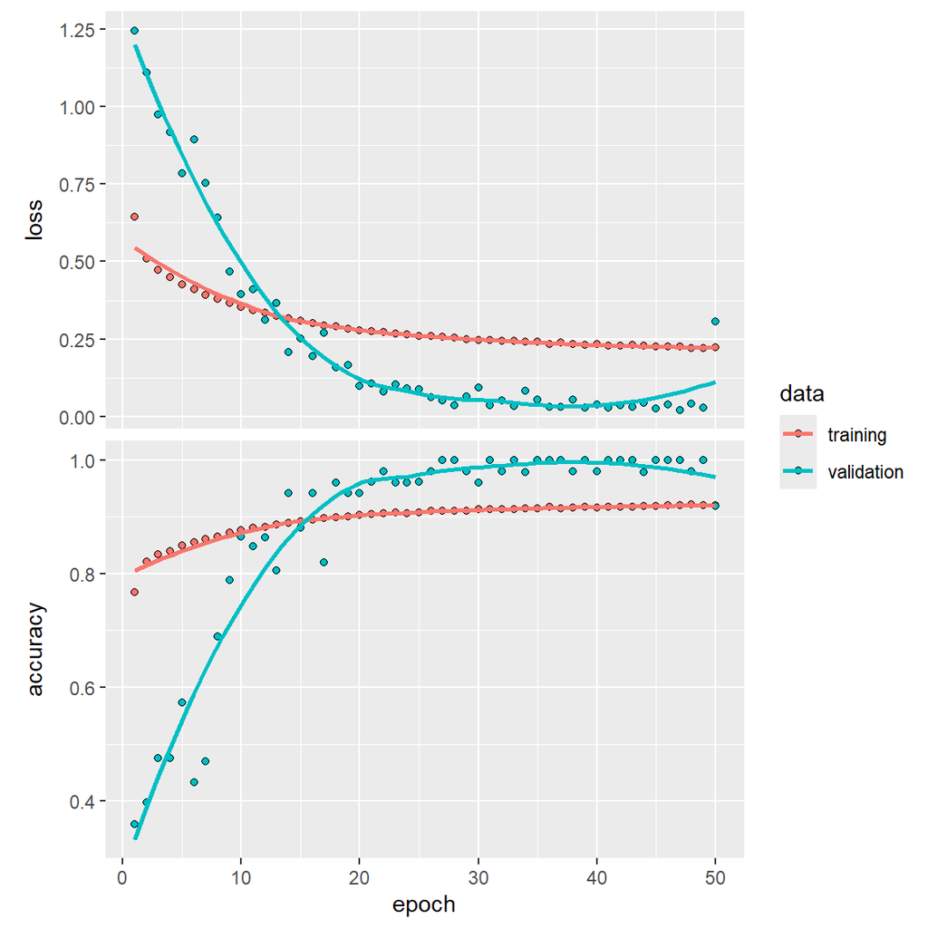

```r
history <- readRDS(file.path(ruta,"history_PM25.rds"))
plot(history)
```

**Nota**

Se probó el modelo con las siguientes combinaciones:

- Upsampling ratio igual a 0.5 y pesos
- Upsampling ratio igual a 0.5 sin pesos
- Upsampling ratio igual a 1 y pesos
- Upsampling ratio igual a 0.5 sin pesos

Todo esto a su vez combinado cada vez con tres y con cuatro capas de red neuronal. Los mejores resultados se obtuvieron con cuatro capas y con la tercera opción aplicando upsampling de ratio 1 y con pesos. Además, se probaron distintos pesos hasta obtener los más adecuados.

En resumen, los resultados con `val_accuracy = 1` no indican un error ni algo raro, sino que reflejan la facilidad del modelo para aprender en un entorno balanceado artificialmente. El rendimiento en el conjunto de prueba, más realista y desequilibrado, es el que realmente debe guiar la evaluación del modelo, que será obtenido en los siguientes apartados.

## 3.7. Evaluación del modelo

En esta etapa se evalúa el rendimiento del modelo utilizando el conjunto de prueba, el cual no se utilizó durante el entrenamiento ni en la validación. La evaluación devuelve dos métricas principales:

- Loss (pérdida): mide qué tan lejos están las predicciones del modelo respecto a las clases reales.
- Accuracy (precisión): indica el porcentaje de predicciones correctas.

```r
model %>% evaluate(x_test, y_test)
```

```
## 251/251 - 0s - loss: 0.2779 - accuracy: 0.8924 - 416ms/epoch - 2ms/step
```

```
##      loss  accuracy
## 0.2778855 0.8924288
```

## 3.8 Predicciones y resultados

En esta etapa se generan las predicciones del modelo sobre el conjunto de prueba, para luego analizar su rendimiento detalladamente a través de una matriz de confusión.

```r
# Predicciones
pred_probs <- model %>% predict(x_test)
```

```
## 251/251 - 0s - 317ms/epoch - 1ms/step
```

```r
pred_classes <- apply(pred_probs, 1, which.max)
true_classes <- apply(y_test, 1, which.max)

# Matriz de confusión
confusionMatrix(
  factor(pred_classes),
  factor(true_classes)
)
```

```
## Confusion Matrix and Statistics
##
##           Reference
## Prediction    1    2    3    4
##          1 1175  578    2    2
##          2  138 5894    1    4
##          3   37   78   56    2
##          4    3   16    0   18
##
## Overall Statistics
##
##                Accuracy : 0.8924
##                  95% CI : (0.8854, 0.8991)
##     No Information Rate : 0.8203
##     P-Value [Acc > NIR] : < 2.2e-16
##
##                   Kappa : 0.6873
##
##  Mcnemar's Test P-Value : < 2.2e-16
##
## Statistics by Class:
##
##                      Class: 1 Class: 2 Class: 3 Class: 4
## Sensitivity            0.8684   0.8977 0.949153 0.692308
## Specificity            0.9125   0.9006 0.985274 0.997618
## Pos Pred Value         0.6688   0.9763 0.323699 0.486486
## Neg Pred Value         0.9715   0.6584 0.999617 0.998996
## Prevalence             0.1690   0.8203 0.007371 0.003248
## Detection Rate         0.1468   0.7364 0.006997 0.002249
## Detection Prevalence   0.2195   0.7542 0.021614 0.004623
## Balanced Accuracy      0.8905   0.8991 0.967213 0.844963
```

```r
# Asegura que ambos factores tengan los niveles 0, 1, 2, 3
niveles <- c(0, 1, 2, 3)

results <- data.frame(
  prediction = factor(pred_classes - 1, levels = niveles),
  truth = factor(true_classes - 1, levels = niveles)
)

metrics(results, truth, prediction)
```

```
## # A tibble: 2 × 3
##   .metric  .estimator .estimate
##   <chr>    <chr>          <dbl>
## 1 accuracy multiclass     0.892
## 2 kap      multiclass     0.687
```

```r
f_meas(results, truth, prediction, estimator = "macro")
```

```
## # A tibble: 1 × 3
##   .metric .estimator .estimate
##   <chr>   <chr>          <dbl>
## 1 f_meas  macro          0.686
```

```r
precision(results, truth, prediction, estimator = "macro")
```

```
## # A tibble: 1 × 3
##   .metric   .estimator .estimate
##   <chr>     <chr>          <dbl>
## 1 precision macro          0.614
```

```r
recall(results, truth, prediction, estimator = "macro")
```

```
## # A tibble: 1 × 3
##   .metric .estimator .estimate
##   <chr>   <chr>          <dbl>
## 1 recall  macro          0.852
```

Estos resultados permiten concluir que el modelo tiene un desempeño robusto en general, aunque existen oportunidades para optimizar la clasificación en ciertas clases con menor precisión.

# 4 Comparación de Modelos

En esta sección se comparan los modelos de clasificación entrenados: SVM con kernel radial, Random Forest (RF), Gradient Boosting Machine (GBM) y una Red Neuronal (RN). La evaluación se realiza mediante diversas métricas de rendimiento.

## 4.1 Métricas Comparativas

Se recopilaron las métricas de los modelos tradicionales a partir de los resultados de `resamples()` y se añadieron manualmente los valores obtenidos para la red neuronal.

```r
# Definir métricas a considerar
metricas_a_maximizar <- c("Accuracy", "Kappa", "Mean_Balanced_Accuracy",
                          "Mean_F1", "Mean_Neg_Pred_Value", "Mean_Pos_Pred_Value", "Mean_Precision", "Mean_Recall",
                          "Mean_Sensitivity", "Mean_Specificity")
metricas_a_minimizar <- c("logLoss")
metricas_incluir <- c(metricas_a_maximizar, metricas_a_minimizar)

# Extraer estadísticas de modelos tradicionales
resumen <- summary(resamples_models)

# Convertir métricas a formato largo
df_metricas <- bind_rows(
  lapply(names(resumen$statistics), function(met) {
    data.frame(
      Métrica = met,
      Modelo = rownames(resumen$statistics[[met]]),
      Valor = resumen$statistics[[met]][, "Mean"],
      row.names = NULL
    )
  })
)

# Filtrar métricas relevantes
df_metricas <- df_metricas %>% filter(Métrica %in% metricas_incluir)

# Pasar a formato ancho
tabla_comparativa <- df_metricas %>%
  pivot_wider(names_from = Modelo, values_from = Valor)

# Métricas Red Neuronal
nn_metricas <- tibble::tibble(
  Métrica = c("Accuracy", "Kappa", "Mean_Balanced_Accuracy",
              "Mean_F1",  "Mean_Neg_Pred_Value", "Mean_Pos_Pred_Value", "Mean_Precision", "Mean_Recall",
              "Mean_Sensitivity", "Mean_Specificity", "logLoss"),
  Red_Neuronal = c(
    0.8924,
    0.6873,
    mean(c(0.8905, 0.8991, 0.9672, 0.8450)),
    0.686,
    mean(c(0.9715, 0.6584, 0.9996, 0.9990)),
    mean(c(0.6688, 0.9763, 0.3237, 0.4865)),
    0.614,
    0.852,
    mean(c(0.8684, 0.8977, 0.9492, 0.6923)),
    mean(c(0.9125, 0.9006, 0.9853, 0.9976)),
    0.2779
  )
)

# Combinar tabla
tabla_completa <- tabla_comparativa %>%
  left_join(nn_metricas, by = "Métrica")

# Redondear
tabla_completa <- tabla_completa %>%
  mutate(across(SVM:Red_Neuronal, ~ round(., 4)))

# Eliminar métricas con todos los valores NA
tabla_completa <- tabla_completa %>%
  filter(rowSums(!is.na(across(SVM:Red_Neuronal))) > 0)

# Resaltar mejores valores
tabla_resaltada <- tabla_completa %>%
  rowwise() %>%
  mutate(
    Mejor = case_when(
      Métrica %in% metricas_a_maximizar ~ max(c_across(SVM:Red_Neuronal), na.rm = TRUE),
      Métrica %in% metricas_a_minimizar ~ min(c_across(SVM:Red_Neuronal), na.rm = TRUE)
    ),
    SVM = ifelse(SVM == Mejor, cell_spec(SVM, color = "white", background = "green"), as.character(SVM)),
    RF = ifelse(RF == Mejor, cell_spec(RF, color = "white", background = "green"), as.character(RF)),
    GBM = ifelse(GBM == Mejor, cell_spec(GBM, color = "white", background = "green"), as.character(GBM)),
    Red_Neuronal = ifelse(Red_Neuronal == Mejor, cell_spec(Red_Neuronal, color = "white", background = "green"), as.character(Red_Neuronal))
  ) %>%
  select(-Mejor)

# Mostrar tabla
kable(tabla_resaltada, escape = FALSE, format = "html", caption = "Comparación de métricas por modelo predictivo") %>%
  kable_styling(full_width = FALSE, position = "center")
```

Comparación de métricas por modelo predictivo

| Métrica | SVM | RF | GBM | Red_Neuronal |
| --- | --- | --- | --- | --- |
| Accuracy | 0.8872 | 0.9669 | 0.8925 | 0.8924 |
| Kappa | 0.6594 | 0.8898 | 0.6812 | 0.6873 |
| logLoss | 0.3209 | 0.1235 | 0.2996 | 0.2779 |
| Mean_Balanced_Accuracy | 0.8063 | 0.9242 | 0.8794 | 0.9004 |
| Mean_F1 | 0.6373 | 0.8477 | 0.6119 | 0.686 |
| Mean_Neg_Pred_Value | 0.9029 | 0.9721 | 0.9078 | 0.9071 |
| Mean_Pos_Pred_Value | 0.6435 | 0.8284 | 0.5475 | 0.6138 |
| Mean_Precision | 0.6435 | 0.8284 | 0.5475 | 0.614 |
| Mean_Recall | 0.6787 | 0.8747 | 0.8166 | 0.852 |
| Mean_Sensitivity | 0.6787 | 0.8747 | 0.8166 | 0.8519 |
| Mean_Specificity | 0.9338 | 0.9738 | 0.9422 | 0.949 |

## 4.2 Resumen de Resultados y Análisis Comparativo

Se evalúan cuatro modelos predictivos: SVM, Random Forest (RF), GBM y una Red Neuronal, para comparar su desempeño en un problema de clasificación multiclase. Para el manejo del desbalance de clases, se aplican técnicas distintas: **SMOTE** en los modelos tradicionales (SVM, RF, GBM) y **upsampling** en la red neuronal, ya que esta última presenta mejores resultados con esta técnica.

### 4.2.1 Rendimiento General de los Modelos

- Random Forest presenta el mejor desempeño general, con la mayor **accuracy (0.967)** y **Kappa (0.890)**, indicando un ajuste excelente y alta capacidad para predecir correctamente las clases. También muestra la menor pérdida logarítmica (**logLoss 0.124**), lo que refleja predicciones confiables y calibradas.
- La Red Neuronal y GBM presentan resultados similares en accuracy (~0.89) y Kappa (0.69 y 0.68 respectivamente). Sin embargo, la red neuronal alcanza mejores valores en métricas como **Mean_Balanced_Accuracy (0.900 vs 0.879)**, **Mean_F1 (0.686 vs 0.612)** y **Mean_Recall (0.852 vs 0.817)**, lo que indica un mejor equilibrio entre precisión y sensibilidad.
- SVM es el modelo con menor desempeño, con accuracy de 0.887 y Kappa de 0.659, consistentemente inferior en la mayoría de las métricas.

### 4.2.2 Motivos del menor desempeño de SVM

- La técnica SMOTE aplicada en SVM puede no ser la más efectiva para este conjunto de datos o para el kernel seleccionado, lo que puede derivar en un modelo menos estable o menos capaz de generalizar.
- SVM puede ser sensible a la dimensionalidad y distribución de los datos, y si no se ajustan correctamente hiperparámetros como costo o kernel, puede tener dificultades para capturar patrones complejos.
- La diferencia en las estrategias de balanceo (SMOTE vs upsampling) puede afectar el aprendizaje. La red neuronal se beneficia más del upsampling, que preserva la distribución real de las muestras replicadas, mientras que SMOTE genera ejemplos sintéticos que pueden introducir ruido o solapamiento.

## 4.3 Conclusión

### 4.3.1 Pregunta 1. ¿Cuáles son las características de las zonas con alta contaminación por PM2.5?

Como se ha podido comprobar en el primer apartado de esta práctica,eEstas zonas presentan en general los valores más altos de concentración media de NO₂ (`NO2_annualMean`) y NO (`NO_annualMean`). También muestran un número elevado de días con superación de partículas PM10 (`PM10_daysOver50`) y niveles altos de ozono en sus métricas de máxima (`O3_dailyMaxAnnualMean` y `O3_dailyHourlyMax`).

### 4.3.2 Pregunta 2. ¿Cuáles son las características de las zonas con baja contaminación por PM2.5?

Por su parte, las zonas de baja contaminación se caracterizan por tener las concentraciones más bajas de PM2.5 y también de otros contaminantes como NO, NO₂ y PM10. Además, son las que presentan menor número de días con superación de los límites de ozono y partículas.

### 4.3.4 Pregunta 4. ¿Cuáles son las variables más relevantes para predecir la contaminación por PM2.5?

La selección de variables se realizó inicialmente mediante Análisis de Componentes Principales (PCA) para evaluar la importancia relativa de las variables, y posteriormente se empleó la técnica de Eliminación Recursiva de Variables (RFE) para seleccionar aquellas con mayor impacto en el rendimiento predictivo. Los resultados de RFE indicaron que las variables seleccionadas, `PM10_annualMean`, `bundesland`, `PM10_daysOver50`, `NO_annualMean`, `NO2_annualMean` y `O3_annualMean`contribuyen significativamente a la precisión del modelo, confirmando que estas variables específicas tienen un rol fundamental en la predicción de los niveles de PM2.5.